Today, we will create a catboost model that predict behavior to retain customers. We will analyze all relevant customer data and develop focused customer retention programs.

# Data

This dataset is about predicting whether a customer will change telecommunications provider, something known as "churning".

The training dataset contains 4250 samples. Each sample contains 19 features and 1 boolean variable "churn" which indicates the class of the sample. The 19 input features and 1 target variable are:

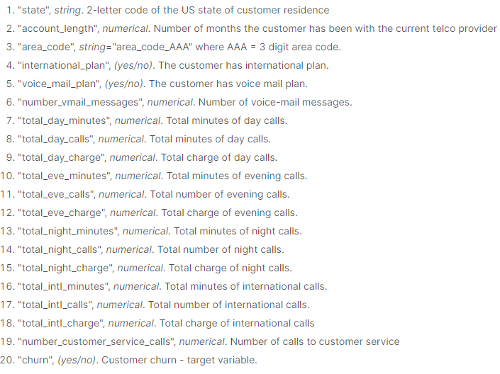

- After analyzing data and data dictionary we see that we have a **classification** problem.
- We wil make classification on the target variable **Churn**.
- For this purpose we will look at the balance of the target variable.
- Since our target variable has imblanced data we are not going to use **Accuracy** score.
- Based on the problem on the hand, we will use **Recall** score.

# Exploratory Data Analysis

```python
# importing plotly and cufflinks in offline mode
import cufflinks as cf
import lightgbm as lgb
import matplotlib.pyplot as plt
import numpy as np
import optuna
import pandas as pd
import plotly.offline
import seaborn as sns

from catboost import CatBoostClassifier
from sklearn.metrics import (
    accuracy_score,
    auc,
    classification_report,
    confusion_matrix,
    f1_score,
    plot_confusion_matrix,
    plot_roc_curve,
    precision_score,
    recall_score,
    roc_auc_score,
    roc_curve,
)
from sklearn.model_selection import cross_val_predict, cross_val_score, train_test_split
from sklearn.preprocessing import (
    LabelEncoder,
    OneHotEncoder,
    PowerTransformer,
    StandardScaler,
)
from xgboost import XGBClassifier

cf.go_offline()
cf.set_config_file(offline=False, world_readable=True)


import warnings

import missingno as msno
import plotly
import plotly.express as px
import plotly.figure_factory as ff
import plotly.graph_objs as go
import plotly.offline as py
import shap
from plotly.offline import iplot
from plotly.subplots import make_subplots

warnings.filterwarnings("ignore")
```

```python
#all my data is stored in locally stored database, that's why I need this step
cred = {
    "host": "8.tcp.ngrok.io:10127",
    "dbname": "***",
    "user": "***",
    "password": "",
}
from sqlalchemy import create_engine

con = create_engine(
    f'postgresql://{cred["user"]}:{cred["password"]}@{cred["host"]}/{cred["dbname"]}'
)


def select(sql):
    return pd.read_sql(sql, con)
```

```python
sql = """SELECT *
FROM customer_churn2"""
data = select(sql)
```

```python
df1 = data.copy()
```

```python
df1.head()
```

|  | index | state | account_length | area_code | international_plan | voice_mail_plan | number_vmail_messages | total_day_minutes | total_day_calls | total_day_charge | ... | total_eve_calls | total_eve_charge | total_night_minutes | total_night_calls | total_night_charge | total_intl_minutes | total_intl_calls | total_intl_charge | number_customer_service_calls | churn |
| --- | --- | --- | --- | --- | --- | --- | --- | --- | --- | --- | --- | --- | --- | --- | --- | --- | --- | --- | --- | --- | --- |
| 0 | 0 | OH | 107 | area_code_415 | no | yes | 26 | 161.6 | 123 | 27.47 | ... | 103 | 16.62 | 254.4 | 103 | 11.45 | 13.7 | 3 | 3.70 | 1 | no |
| 1 | 1 | NJ | 137 | area_code_415 | no | no | 0 | 243.4 | 114 | 41.38 | ... | 110 | 10.30 | 162.6 | 104 | 7.32 | 12.2 | 5 | 3.29 | 0 | no |
| 2 | 2 | OH | 84 | area_code_408 | yes | no | 0 | 299.4 | 71 | 50.90 | ... | 88 | 5.26 | 196.9 | 89 | 8.86 | 6.6 | 7 | 1.78 | 2 | no |
| 3 | 3 | OK | 75 | area_code_415 | yes | no | 0 | 166.7 | 113 | 28.34 | ... | 122 | 12.61 | 186.9 | 121 | 8.41 | 10.1 | 3 | 2.73 | 3 | no |
| 4 | 4 | MA | 121 | area_code_510 | no | yes | 24 | 218.2 | 88 | 37.09 | ... | 108 | 29.62 | 212.6 | 118 | 9.57 | 7.5 | 7 | 2.03 | 3 | no |

```python
print(f"We have {df1.shape[0]} rows and {df1.shape[1]} columns in our dataset.")
```

```
We have 4250 rows and 21 columns in our dataset.
```

```python
df1.duplicated().sum()
```

```
0
```

```python
def missing(df1):
    missing_number = df1.isnull().sum().sort_values(ascending=False)
    missing_percent = (df1.isnull().sum() / df1.isnull().count()).sort_values(
        ascending=False
    )
    missing_values = pd.concat(
        [missing_number, missing_percent],
        axis=1,
        keys=["Missing_Number", "Missing_Percent"],
    )
    return missing_values


missing(df1)
```

|  | Missing_Number | Missing_Percent |
| --- | --- | --- |
| index | 0 | 0.0 |
| total_eve_calls | 0 | 0.0 |
| number_customer_service_calls | 0 | 0.0 |
| total_intl_charge | 0 | 0.0 |
| total_intl_calls | 0 | 0.0 |
| ... | ... | ... |
| voice_mail_plan | 0 | 0.0 |
| international_plan | 0 | 0.0 |
| area_code | 0 | 0.0 |
| account_length | 0 | 0.0 |
| churn | 0 | 0.0 |

We have neither duplicated nor missing value (some deeper checks might always be needed to be 100% sure).

```python
df1.info()
```

```
<class 'pandas.core.frame.DataFrame'>
RangeIndex: 4250 entries, 0 to 4249
Data columns (total 21 columns):
 #   Column                         Non-Null Count  Dtype
---  ------                         --------------  -----
 0   index                          4250 non-null   int64
 1   state                          4250 non-null   object
 2   account_length                 4250 non-null   int64
 3   area_code                      4250 non-null   object
 4   international_plan             4250 non-null   object
 5   voice_mail_plan                4250 non-null   object
 6   number_vmail_messages          4250 non-null   int64
 7   total_day_minutes              4250 non-null   float64
 8   total_day_calls                4250 non-null   int64
 9   total_day_charge               4250 non-null   float64
 10  total_eve_minutes              4250 non-null   float64
 11  total_eve_calls                4250 non-null   int64
 12  total_eve_charge               4250 non-null   float64
 13  total_night_minutes            4250 non-null   float64
 14  total_night_calls              4250 non-null   int64
 15  total_night_charge             4250 non-null   float64
 16  total_intl_minutes             4250 non-null   float64
 17  total_intl_calls               4250 non-null   int64
 18  total_intl_charge              4250 non-null   float64
 19  number_customer_service_calls  4250 non-null   int64
 20  churn                          4250 non-null   object
dtypes: float64(8), int64(8), object(5)
memory usage: 697.4+ KB
```

**Based on our preliminary analysis, we conclude that**:

## Target Variable

```python
df1.churn.value_counts()
```

```
no     3652
yes     598
Name: churn, dtype: int64
```

```python
df1.churn.value_counts(normalize=True)
```

```
no     0.859294
yes    0.140706
Name: churn, dtype: float64
```

```python
y = df1["churn"]
print(
    f"Percentage of Churn:  {round(y.value_counts(normalize=True)[1]*100,2)} %  --> ({y.value_counts()[1]} customers)"
)
print(
    f"Percentage Non_Churn: {round(y.value_counts(normalize=True)[0]*100,2)}  %  --> ({y.value_counts()[0]} customers)"
)
```

```
Percentage of Churn:  14.07 %  --> (598 customers)
Percentage Non_Churn: 85.93  %  --> (3652 customers)
```

```python
y.iplot(kind="hist", title="Churns vs. NonChurns");
```

[interactive chart not shown]

```python
# We converted type of "churn" from object to int
le = LabelEncoder()
df1.churn = le.fit_transform(df1.churn)
```

```python
df1.info()
```

```
<class 'pandas.core.frame.DataFrame'>
RangeIndex: 4250 entries, 0 to 4249
Data columns (total 21 columns):
 #   Column                         Non-Null Count  Dtype
---  ------                         --------------  -----
 0   index                          4250 non-null   int64
 1   state                          4250 non-null   object
 2   account_length                 4250 non-null   int64
 3   area_code                      4250 non-null   object
 4   international_plan             4250 non-null   object
 5   voice_mail_plan                4250 non-null   object
 6   number_vmail_messages          4250 non-null   int64
 7   total_day_minutes              4250 non-null   float64
 8   total_day_calls                4250 non-null   int64
 9   total_day_charge               4250 non-null   float64
 10  total_eve_minutes              4250 non-null   float64
 11  total_eve_calls                4250 non-null   int64
 12  total_eve_charge               4250 non-null   float64
 13  total_night_minutes            4250 non-null   float64
 14  total_night_calls              4250 non-null   int64
 15  total_night_charge             4250 non-null   float64
 16  total_intl_minutes             4250 non-null   float64
 17  total_intl_calls               4250 non-null   int64
 18  total_intl_charge              4250 non-null   float64
 19  number_customer_service_calls  4250 non-null   int64
 20  churn                          4250 non-null   int64
dtypes: float64(8), int64(9), object(4)
memory usage: 697.4+ KB
```

- We converted **churn** column into numeric type.

```python
numerical = df1.select_dtypes(include="number").columns

categorical = df1.select_dtypes(include="object").columns

print(f"Numerical Columns:  {df1[numerical].columns}")
print("\n")
print(f"Categorical Columns: {df1[categorical].columns}")
```

```
Numerical Columns:  Index(['index', 'account_length', 'number_vmail_messages', 'total_day_minutes',
       'total_day_calls', 'total_day_charge', 'total_eve_minutes',
       'total_eve_calls', 'total_eve_charge', 'total_night_minutes',
       'total_night_calls', 'total_night_charge', 'total_intl_minutes',
       'total_intl_calls', 'total_intl_charge',
       'number_customer_service_calls', 'churn'],
      dtype='object')


Categorical Columns: Index(['state', 'area_code', 'international_plan', 'voice_mail_plan'], dtype='object')
```

- For ease of usage, we got the list of the **numerical** and **categorical** features.

## Numerical Features

```python
col_int = []

for col in numerical:
    if df1[col].dtype == "int64":
        col_int.append(col)

col_int.remove("churn")
col_int
```

```
['index',
 'account_length',
 'number_vmail_messages',
 'total_day_calls',
 'total_eve_calls',
 'total_night_calls',
 'total_intl_calls',
 'number_customer_service_calls']
```

```python
for i in col_int:
    df1[i] = df1[i].astype(float)
```

- We have just converted all types of all columns (except for **churn**) with int64 into float type.

```python
df1.info()
```

```
<class 'pandas.core.frame.DataFrame'>
RangeIndex: 4250 entries, 0 to 4249
Data columns (total 21 columns):
 #   Column                         Non-Null Count  Dtype
---  ------                         --------------  -----
 0   index                          4250 non-null   float64
 1   state                          4250 non-null   object
 2   account_length                 4250 non-null   float64
 3   area_code                      4250 non-null   object
 4   international_plan             4250 non-null   object
 5   voice_mail_plan                4250 non-null   object
 6   number_vmail_messages          4250 non-null   float64
 7   total_day_minutes              4250 non-null   float64
 8   total_day_calls                4250 non-null   float64
 9   total_day_charge               4250 non-null   float64
 10  total_eve_minutes              4250 non-null   float64
 11  total_eve_calls                4250 non-null   float64
 12  total_eve_charge               4250 non-null   float64
 13  total_night_minutes            4250 non-null   float64
 14  total_night_calls              4250 non-null   float64
 15  total_night_charge             4250 non-null   float64
 16  total_intl_minutes             4250 non-null   float64
 17  total_intl_calls               4250 non-null   float64
 18  total_intl_charge              4250 non-null   float64
 19  number_customer_service_calls  4250 non-null   float64
 20  churn                          4250 non-null   int64
dtypes: float64(16), int64(1), object(4)
memory usage: 697.4+ KB
```

```python
df1[numerical].describe()
# df1.describe()
```

|  | index | account_length | number_vmail_messages | total_day_minutes | total_day_calls | total_day_charge | total_eve_minutes | total_eve_calls | total_eve_charge | total_night_minutes | total_night_calls | total_night_charge | total_intl_minutes | total_intl_calls | total_intl_charge | number_customer_service_calls | churn |
| --- | --- | --- | --- | --- | --- | --- | --- | --- | --- | --- | --- | --- | --- | --- | --- | --- | --- |
| count | 4250.000000 | 4250.000000 | 4250.000000 | 4250.000000 | 4250.000000 | 4250.000000 | 4250.000000 | 4250.000000 | 4250.000000 | 4250.000000 | 4250.000000 | 4250.000000 | 4250.000000 | 4250.000000 | 4250.000000 | 4250.000000 | 4250.000000 |
| mean | 2124.500000 | 100.236235 | 7.631765 | 180.259600 | 99.907294 | 30.644682 | 200.173906 | 100.176471 | 17.015012 | 200.527882 | 99.839529 | 9.023892 | 10.256071 | 4.426353 | 2.769654 | 1.559059 | 0.140706 |
| std | 1227.013651 | 39.698401 | 13.439882 | 54.012373 | 19.850817 | 9.182096 | 50.249518 | 19.908591 | 4.271212 | 50.353548 | 20.093220 | 2.265922 | 2.760102 | 2.463069 | 0.745204 | 1.311434 | 0.347759 |
| min | 0.000000 | 1.000000 | 0.000000 | 0.000000 | 0.000000 | 0.000000 | 0.000000 | 0.000000 | 0.000000 | 0.000000 | 0.000000 | 0.000000 | 0.000000 | 0.000000 | 0.000000 | 0.000000 | 0.000000 |
| 25% | 1062.250000 | 73.000000 | 0.000000 | 143.325000 | 87.000000 | 24.365000 | 165.925000 | 87.000000 | 14.102500 | 167.225000 | 86.000000 | 7.522500 | 8.500000 | 3.000000 | 2.300000 | 1.000000 | 0.000000 |
| 50% | 2124.500000 | 100.000000 | 0.000000 | 180.450000 | 100.000000 | 30.680000 | 200.700000 | 100.000000 | 17.060000 | 200.450000 | 100.000000 | 9.020000 | 10.300000 | 4.000000 | 2.780000 | 1.000000 | 0.000000 |
| 75% | 3186.750000 | 127.000000 | 16.000000 | 216.200000 | 113.000000 | 36.750000 | 233.775000 | 114.000000 | 19.867500 | 234.700000 | 113.000000 | 10.560000 | 12.000000 | 6.000000 | 3.240000 | 2.000000 | 0.000000 |
| max | 4249.000000 | 243.000000 | 52.000000 | 351.500000 | 165.000000 | 59.760000 | 359.300000 | 170.000000 | 30.540000 | 395.000000 | 175.000000 | 17.770000 | 20.000000 | 20.000000 | 5.400000 | 9.000000 | 1.000000 |

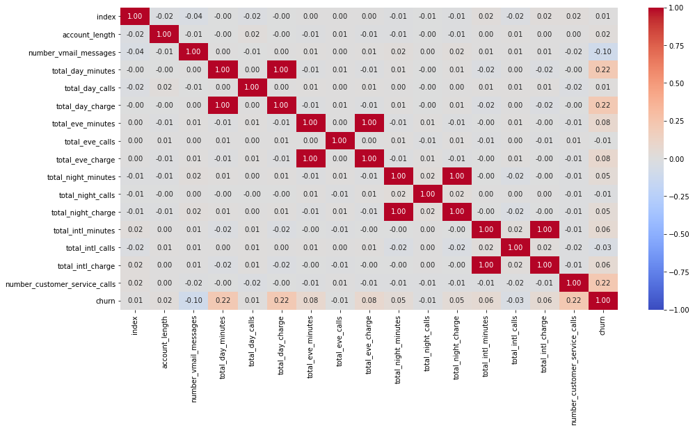

```python
plt.figure(figsize=(16, 8))
sns.heatmap(
    df1[numerical].corr(),
    annot=True,
    fmt=".2f",
    vmin=-1,
    vmax=1,
    center=0,
    cmap="coolwarm",
);
```

- We can see in heatmap that we have some multicollinerity.
- We need to drop one of each highly correleated column pairs.

```python
drop_col = [
    "total_day_charge",
    "total_eve_charge",
    "total_night_charge",
    "total_intl_charge",
]
df1 = df1.drop(drop_col, axis=1)
df1.shape
```

```
(4250, 17)
```

```python
numerical = df1.select_dtypes(include="number").columns
numerical
```

```
Index(['index', 'account_length', 'number_vmail_messages', 'total_day_minutes',
       'total_day_calls', 'total_eve_minutes', 'total_eve_calls',
       'total_night_minutes', 'total_night_calls', 'total_intl_minutes',
       'total_intl_calls', 'number_customer_service_calls', 'churn'],
      dtype='object')
```

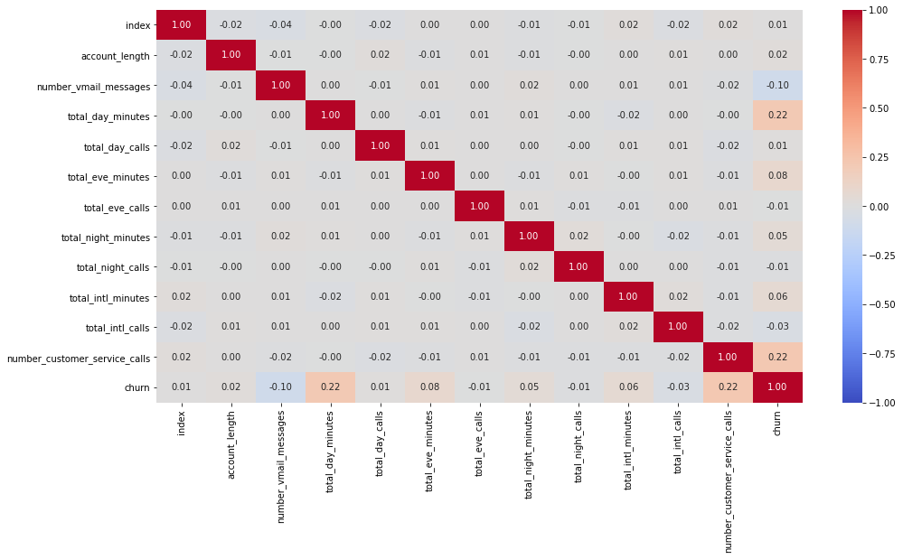

```python
plt.figure(figsize=(16, 8))
sns.heatmap(
    df1[numerical].corr(),
    annot=True,
    fmt=".2f",
    vmin=-1,
    vmax=1,
    center=0,
    cmap="coolwarm",
);
```

- We got rid of multicollinear columns.
- **total_day_minutes** has the highest correleation with **churn**.
- Overall, there is low correleations among features.

## Categorical Features

```python
df1[categorical].nunique()
```

```
state                 51
area_code              3
international_plan     2
voice_mail_plan        2
dtype: int64
```

- Great news! We do not have a high cardinality or zero variance issues.

```python
for column in df1[categorical]:
    print(f"{column}: {df1[column].unique()}")
```

```
state: ['OH' 'NJ' 'OK' 'MA' 'MO' 'LA' 'WV' 'IN' 'RI' 'IA' 'MT' 'NY' 'ID' 'VA'
 'TX' 'FL' 'CO' 'AZ' 'SC' 'WY' 'HI' 'NH' 'AK' 'GA' 'MD' 'AR' 'WI' 'OR'
 'MI' 'DE' 'UT' 'CA' 'SD' 'NC' 'WA' 'MN' 'NM' 'NV' 'DC' 'VT' 'KY' 'ME'
 'MS' 'AL' 'NE' 'KS' 'TN' 'IL' 'PA' 'CT' 'ND']
area_code: ['area_code_415' 'area_code_408' 'area_code_510']
international_plan: ['no' 'yes']
voice_mail_plan: ['yes' 'no']
```

### state vs. churn

```python
for i in df1["state"].unique():
    print(
        f'A customer from state of {i} has a probability of {round(df1[df1["state"]==i]["churn"].mean()*100,2)} % churn.'
    )
```

```
A customer from state of OH has a probability of 12.63 % churn.
A customer from state of NJ has a probability of 27.08 % churn.
A customer from state of OK has a probability of 20.51 % churn.
A customer from state of MA has a probability of 15.73 % churn.
A customer from state of MO has a probability of 12.5 % churn.
A customer from state of LA has a probability of 10.14 % churn.
A customer from state of WV has a probability of 13.67 % churn.
A customer from state of IN has a probability of 15.66 % churn.
A customer from state of RI has a probability of 6.9 % churn.
A customer from state of IA has a probability of 11.29 % churn.
A customer from state of MT has a probability of 21.25 % churn.
A customer from state of NY has a probability of 16.67 % churn.
A customer from state of ID has a probability of 11.32 % churn.
A customer from state of VA has a probability of 5.0 % churn.
A customer from state of TX has a probability of 19.39 % churn.
A customer from state of FL has a probability of 11.84 % churn.
A customer from state of CO has a probability of 11.25 % churn.
A customer from state of AZ has a probability of 9.09 % churn.
A customer from state of SC has a probability of 19.44 % churn.
A customer from state of WY has a probability of 10.53 % churn.
A customer from state of HI has a probability of 5.19 % churn.
A customer from state of NH has a probability of 12.82 % churn.
A customer from state of AK has a probability of 6.56 % churn.
A customer from state of GA has a probability of 10.94 % churn.
A customer from state of MD has a probability of 22.09 % churn.
A customer from state of AR has a probability of 15.49 % churn.
A customer from state of WI has a probability of 7.45 % churn.
A customer from state of OR has a probability of 15.15 % churn.
A customer from state of MI has a probability of 17.24 % churn.
A customer from state of DE has a probability of 16.25 % churn.
A customer from state of UT has a probability of 12.37 % churn.
A customer from state of CA has a probability of 25.64 % churn.
A customer from state of SD has a probability of 14.67 % churn.
A customer from state of NC has a probability of 8.75 % churn.
A customer from state of WA has a probability of 22.5 % churn.
A customer from state of MN has a probability of 17.59 % churn.
A customer from state of NM has a probability of 12.82 % churn.
A customer from state of NV has a probability of 20.48 % churn.
A customer from state of DC has a probability of 11.11 % churn.
A customer from state of VT has a probability of 11.63 % churn.
A customer from state of KY has a probability of 14.12 % churn.
A customer from state of ME has a probability of 17.98 % churn.
A customer from state of MS has a probability of 18.29 % churn.
A customer from state of AL has a probability of 12.87 % churn.
A customer from state of NE has a probability of 6.85 % churn.
A customer from state of KS has a probability of 17.24 % churn.
A customer from state of TN has a probability of 15.19 % churn.
A customer from state of IL has a probability of 7.59 % churn.
A customer from state of PA has a probability of 11.94 % churn.
A customer from state of CT has a probability of 17.05 % churn.
A customer from state of ND has a probability of 8.96 % churn.
```

```python
fig = px.histogram(data_frame=df1, x="state", color="churn", width=1200, height=400)
fig.show()
```

[interactive chart not shown]

### area_code vs. churn

```python
area_code: ["area_code_415" "area_code_408" "area_code_510"]

print(
    f'A customer with area_code_415 has a probability of {round(df1[df1["area_code"]=="area_code_415"]["churn"].mean()*100,2)} % churn.'
)
print()
print(
    f'A customer with area_code_408 has a probability of {round(df1[df1["area_code"]=="area_code_408"]["churn"].mean()*100,2)} % churn.'
)
print()
print(
    f'A customer with area_code_510 has a probability of {round(df1[df1["area_code"]=="area_code_510"]["churn"].mean()*100,2)} % churn.'
)
```

```
A customer with area_code_415 has a probability of 13.61 % churn.

A customer with area_code_408 has a probability of 14.0 % churn.

A customer with area_code_510 has a probability of 15.06 % churn.
```

```python
fig = px.histogram(data_frame=df1, x="area_code", color="churn", width=420, height=420)
fig.show()
```

[interactive chart not shown]

- It seems that there is not much difference among **area_codes** on churn rate.
- We may drop it later.

### international_plan vs. churn

```python
print(
    f'A customer with an international plan has a probability of {round(df1[df1["international_plan"]=="yes"]["churn"].mean()*100,2)} % churn.'
)
print()
print(
    f'A customer wwithout an international plan has a probability of {round(df1[df1["international_plan"]=="no"]["churn"].mean()*100,2)} % churn.'
)
```

```
A customer with an international plan has a probability of 42.17 % churn.

A customer wwithout an international plan has a probability of 11.18 % churn.
```

```python
fig = px.histogram(
    data_frame=df1, x="international_plan", color="churn", width=420, height=420
)
fig.show()
```

[interactive chart not shown]

- Customers with an international plan is almost 4 times more likely to churn than those without international plan.

### voice_mail_plan vs. churn

```python
print(
    f'A customer with a voice mail plan has a probability of {round(df1[df1["voice_mail_plan"]=="yes"]["churn"].mean()*100,2)} % churn.'
)
print()
print(
    f'A customer wwithout a vocie mail plan has a probability of {round(df1[df1["voice_mail_plan"]=="no"]["churn"].mean()*100,2)} % churn.'
)
```

```
A customer with a voice mail plan has a probability of 7.37 % churn.

A customer wwithout a vocie mail plan has a probability of 16.44 % churn.
```

```python
fig = px.histogram(
    data_frame=df1, x="voice_mail_plan", color="churn", width=420, height=420
)
fig.show()
```

[interactive chart not shown]

**Note1**: If we use extreme values for the **scale_pos_weight**, we can overfit the minority class and model could make worse predictions.

**Note2**: While **CatBoost** and **LightGBM** can handle categorical features, **XGBoost** cannot. You have to convert categorical features before creating your model.

### CatBoost - scale_pos_weight = 5

```python
numerical_1 = [
    "account_length",
    "number_vmail_messages",
    "total_day_minutes",
    "total_day_calls",
    "total_eve_minutes",
    "total_eve_calls",
    "total_night_minutes",
    "total_night_calls",
    "total_intl_minutes",
    "total_intl_calls",
    "number_customer_service_calls",
]
numerical_1
```

```
['account_length',
 'number_vmail_messages',
 'total_day_minutes',
 'total_day_calls',
 'total_eve_minutes',
 'total_eve_calls',
 'total_night_minutes',
 'total_night_calls',
 'total_intl_minutes',
 'total_intl_calls',
 'number_customer_service_calls']
```

```python
accuracy = []
recall = []
roc_auc = []
precision = []


df = data
df1 = df.copy()
le = LabelEncoder()
df1["churn"] = le.fit_transform(df1["churn"])


# for i in numerical_1:
# df1[i] = df1[i].astype(float)


X = df1.drop("churn", axis=1)
y = df1["churn"]

categorical_features_indices = np.where(X.dtypes != np.float)[0]

X_train, X_test, y_train, y_test = train_test_split(
    X, y, test_size=0.3, random_state=42
)

# With scale_pos_weight=5, minority class gets 5 times more impact and 5 times more correction than errors made on the majority class.
catboost_5 = CatBoostClassifier(verbose=False, random_state=0, scale_pos_weight=5)

catboost_5.fit(
    X_train,
    y_train,
    cat_features=categorical_features_indices,
    eval_set=(X_test, y_test),
)
y_pred = catboost_5.predict(X_test)

accuracy.append(round(accuracy_score(y_test, y_pred), 4))
recall.append(round(recall_score(y_test, y_pred), 4))
roc_auc.append(round(roc_auc_score(y_test, y_pred), 4))
precision.append(round(precision_score(y_test, y_pred), 4))

model_names = ["Catboost_adjusted_weight_5"]
result_df1 = pd.DataFrame(
    {
        "Accuracy": accuracy,
        "Recall": recall,
        "Roc_Auc": roc_auc,
        "Precision": precision,
    },
    index=model_names,
)
result_df1
```

|  | Accuracy | Recall | Roc_Auc | Precision |
| --- | --- | --- | --- | --- |
| Catboost_adjusted_weight_5 | 0.9451 | 0.8513 | 0.9067 | 0.8019 |

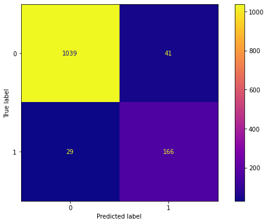

```python
fig, ax = plt.subplots(figsize=(10, 6))
plot_confusion_matrix(catboost_5, X_test, y_test, cmap=plt.cm.plasma, ax=ax);
```